# Loan Data from Prosper

## Investigation Overview

In this investigation, I wanted to look at the Loan amounts and top states and categories based on number of loans. Also I will show what affects the loan status and the APR of the borrower.

## Dataset Overview

This data set contains 113,937 loans with 81 variables on each loan, including loan amount, borrower rate (or interest rate), current loan status, borrower income, and many others.

## Distribution of Loan Amount

Loan Amount in the dataset Varies from 1000 USD to 35000 USD. Customers tend to take loans with values with multiples of 5000, a lot of loans have values 5000,10000,15000 and also 20000 and 25000. Small number of loans have amount more than 25000.

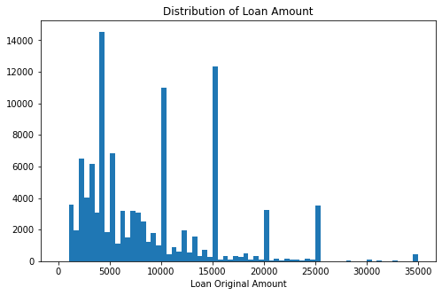

## Top loan category for each state

For each of the top 6 states, we show the top 10 loan categories. Calefornia has the most loans followed by Texas. Debt Consolidation loan type is the most common loan type requested by customers followed by Business and Home improvement

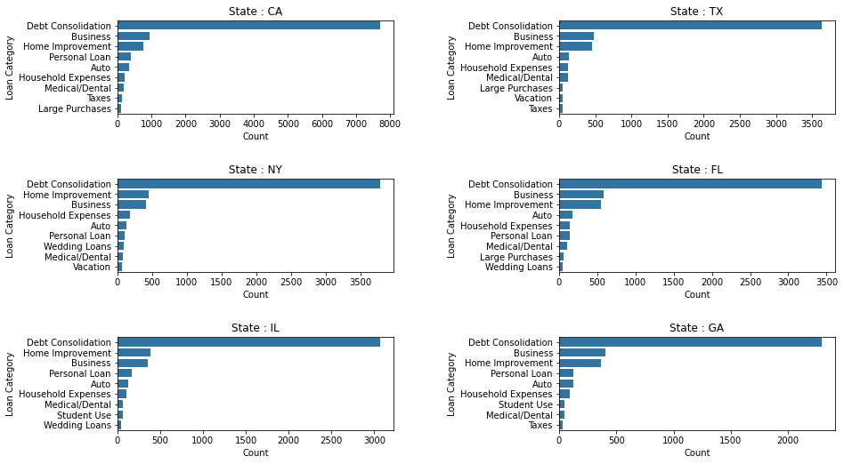

## Employment Status vs. Loan Status

For Employed people, we found out they have lower percentage for their loans to be defaulted or to be charged off than unemployed people which make sense. The employed people have higher probability to pay their loans.

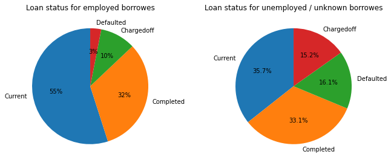

## The ratio of delequent loans for each occupation

For Each occupation (job title) of the top 24, we show the ratio of delequent and non delequent loans. We found out that Nurse, analyst and computer programmer have low delequencies ratio. Clerical and Sales have high delequencies ratio.

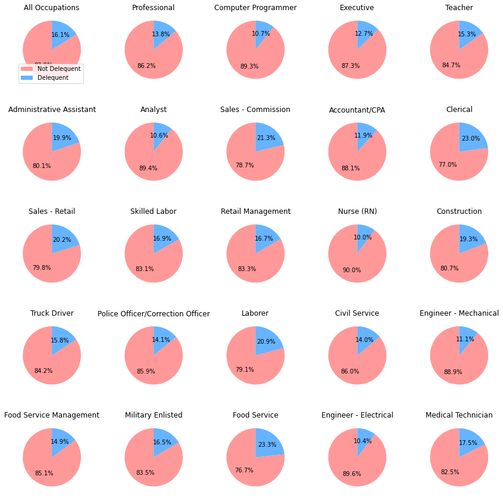

## APR vs Employment status & Home Owning

We can see that -on average- the unemployed people have higher APR (Anual Percentage Rate) for their loans. Also the people who don't own a home have higher average APR (Anual Percentage Rate) for their loans.

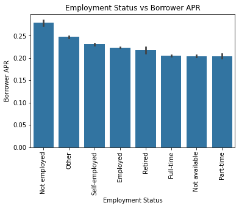

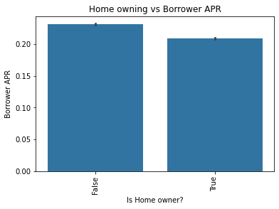

## APR vs State

We show each state and the average APR (Anual percentage rate). We can see that ME and IA states have a low ARP and AL has the highest ARP in average.

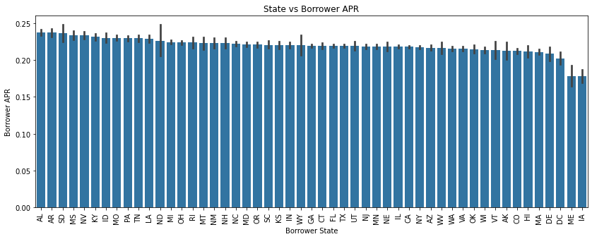